# Chapter 16 ARMD Trial: Modeling Visual Acuity

Randy

9/25/2021

## 16.1 Introduction

The analysis took into account the correlation between visual acuity measurements obtained for the same patient.

To apply the models, we used the function `nlme::gls()` to fit the population-averaged (marginal) models.

## 16.2 A Model with Random Intercepts and Homogeneous Residual Variance

It contains subject-specific random intercepts and homoscedastic residual errors. Consequently, observations for the same individual, which share the random intercept, are correlated with a constant (positive) correlation coefficient.

Marginally, this corresponds to a compound-symmetry correlation structure with a correlation parameter greater than zero.

### 16.2.1 Model Specification

Note that we use a linear time effect, following the findings based on the final marginal model M12.3. However, contrary to these findings, we include the interaction between time and treatment in (16.1), to “enrich” the fixed part of the mean structure. Also, as it will become clear shortly, we simplify the variance-covariance structure.

$$\begin{split}
VISUAL_{it} = & \beta_0 +\beta_1 × VISUAL0_{i} +\beta_2 × TIME_{it} +\beta_3 × TREAT_{i} +\\
& \beta_4 × TREAT_i × TIME_{it} + \\
& b_{0i} + \epsilon_{it}. (16.1)
\end{split}$$

Note that, formally speaking, the random intercept $b_{0i}$ is a subject-specific deviation from the fixed intercept $b_0$.

It is, however, customary to call $b_{0i}$ a subject-specific random intercept, despite the fact that, actually, $b_0$ and $b_{0i}$ are “coupled” (Sect. 13.2.1) and they both contribute to the subject-specific intercept.

Typically, this convention does not lead to any misunderstanding.

The fixed part of model M16.1 assumes that the average profile is linear in time, with different intercepts and slopes for the placebo and active treatment groups.

The subject-specific profiles are assumed to also be linear in time, with subject-specific (random) intercepts that shift the individual profiles from the average linear trend.

$$\begin{pmatrix}
VISUAL_{i1}\\
VISUAL_{i2}\\
VISUAL_{i3}\\
VISUAL_{i4}
\end{pmatrix} =
\begin{pmatrix}
1 & VISUAL0_i & 4 & TREAT_i & 4 · TREAT_i\\
1 & VISUAL0_i & 12 & TREAT_i & 12 · TREAT_i\\
1 & VISUAL0_i & 24 & TREAT_i & 24 · TREAT_i\\
1 & VISUAL0_i & 52 & TREAT_i & 52 · TREAT_i\\
\end{pmatrix}
\begin{pmatrix}
\beta_0\\
\beta_1\\
\beta_2\\
\beta_3\\
\beta_4\\
\end{pmatrix} +
\begin{pmatrix}
1\\ 1\\ 1\\ 1
\end{pmatrix}
× b_{0i} +
\begin{pmatrix}
\epsilon_{i1}\\
\epsilon_{i2}\\
\epsilon_{i3}\\
\epsilon_{i4}\\
\end{pmatrix}, (16.2)$$

$$\begin{split}
& \pmb y_i \equiv
\begin{pmatrix}
VISUAL_{i1}\\
VISUAL_{i2}\\
VISUAL_{i3}\\
VISUAL_{i4}
\end{pmatrix}\\
& \pmb X_i \equiv
\begin{pmatrix}
1 & VISUAL0_i & 4 & TREAT_i & 4 · TREAT_i\\
1 & VISUAL0_i & 12 & TREAT_i & 12 · TREAT_i\\
1 & VISUAL0_i & 24 & TREAT_i & 24 · TREAT_i\\
1 & VISUAL0_i & 52 & TREAT_i & 52 · TREAT_i\\
\end{pmatrix} \\
& \pmb Z_i \equiv
\begin{pmatrix}
1\\ 1\\ 1\\ 1
\end{pmatrix}\\
& \pmb \beta \equiv
\begin{pmatrix}
\beta_0\\
\beta_1\\
\beta_2\\
\beta_3\\
\beta_4\\
\end{pmatrix} \\
& \pmb \epsilon_i \equiv
\begin{pmatrix}
\epsilon_{i1}\\
\epsilon_{i2}\\
\epsilon_{i3}\\
\epsilon_{i4}\\
\end{pmatrix}\\
& \pmb b_i \equiv b_{0i}
\end{split}$$

$$\begin{split}
\pmb {\mathcal D} \equiv & d_{11}\\
\pmb {\mathcal R}_{i} \equiv & \sigma^2 \pmb I_{4}\\
\pmb {\mathcal V}_i \equiv & \pmb Z_i \pmb {\mathcal D} \pmb Z_i' + \sigma^2 \pmb I_4 \\
= & \begin{pmatrix}
1 \\ 1 \\ 1 \\ 1
\end{pmatrix}
d_{11}
(1 \ \ 1 \ \ 1 \ \ 1 )+
\begin{pmatrix}
\sigma^2 & 0 & 0 & 0 \\
0 & \sigma^2 & 0 & 0 \\
0 & 0 & \sigma^2 & 0 \\
0 & 0 & 0 & \sigma^2 \\
\end{pmatrix} \\ = &
\begin{pmatrix}
\sigma^2 +d_{11} & d_{11} & d_{11} & d_{11} \\
d_{11} & \sigma^2 +d_{11} & d_{11} & d_{11} \\
d_{11} & d_{11} & \sigma^2 +d_{11} & d_{11} \\
d_{11} & d_{11} & d_{11} & \sigma^2 +d_{11}
\end{pmatrix}\\
\rho = & d_{11} / (\sigma^2 + d_{11})
\end{split}$$

```r
library(nlmeU)
data(armd, package = "nlmeU")
## M16.1
(fm16.1 <- lme(visual ~ visual0 + time + treat.f + treat.f:time, random = ~1|subject, data = armd)) # b0i:(16.5)
```

```
## Linear mixed-effects model fit by REML
##   Data: armd
##   Log-restricted-likelihood: -3288.986
##   Fixed: visual ~ visual0 + time + treat.f + treat.f:time
##        (Intercept)            visual0               time      treat.fActive
##         9.28807837         0.82643987        -0.21221595        -2.42200012
## time:treat.fActive
##        -0.04959058
##
## Random effects:
##  Formula: ~1 | subject
##         (Intercept) Residual
## StdDev:    8.978212 8.627514
##
## Number of Observations: 867
## Number of Groups: 234
```

```r
vcov(fm16.1)
```

```
##                    (Intercept)       visual0          time treat.fActive
## (Intercept)         7.19252750 -1.102120e-01 -1.135793e-02  -1.186575434
## visual0            -0.11021200  1.995141e-03 -2.950087e-06   0.001487695
## time               -0.01135793 -2.950087e-06  5.257619e-04   0.011518692
## treat.fActive      -1.18657543  1.487695e-03  1.151869e-02   2.249900005
## time:treat.fActive  0.01137481  2.644510e-06 -5.257615e-04  -0.023948166
##                    time:treat.fActive
## (Intercept)              1.137481e-02
## visual0                  2.644510e-06
## time                    -5.257615e-04
## treat.fActive           -2.394817e-02
## time:treat.fActive       1.126389e-03
```

```r
getVarCov(fm16.1)
```

```
## Random effects variance covariance matrix
##             (Intercept)
## (Intercept)      80.608
##   Standard Deviations: 8.9782
```

```r
summary(fm16.1)
```

```
## Linear mixed-effects model fit by REML
##   Data: armd
##        AIC      BIC    logLik
##   6591.971 6625.286 -3288.986
##
## Random effects:
##  Formula: ~1 | subject
##         (Intercept) Residual
## StdDev:    8.978212 8.627514
##
## Fixed effects:  visual ~ visual0 + time + treat.f + treat.f:time
##                        Value Std.Error  DF   t-value p-value
## (Intercept)         9.288078 2.6818888 631  3.463260  0.0006
## visual0             0.826440 0.0446670 231 18.502244  0.0000
## time               -0.212216 0.0229295 631 -9.255150  0.0000
## treat.fActive      -2.422000 1.4999667 231 -1.614703  0.1077
## time:treat.fActive -0.049591 0.0335617 631 -1.477594  0.1400
##  Correlation:
##                    (Intr) visul0 time   trt.fA
## visual0            -0.920
## time               -0.185 -0.003
## treat.fActive      -0.295  0.022  0.335
## time:treat.fActive  0.126  0.002 -0.683 -0.476
##
## Standardized Within-Group Residuals:
##         Min          Q1         Med          Q3         Max
## -4.18750513 -0.39692515  0.03204783  0.55138252  2.95132118
##
## Number of Observations: 867
## Number of Groups: 234
```

```r
printCoefmat(summary(fm16.1)$tTable,
             has.Pvalue = TRUE,
             P.values = TRUE)
```

```
##                         Value  Std.Error         DF t-value   p-value
## (Intercept)          9.288078   2.681889 631.000000  3.4633 0.0005698 ***
## visual0              0.826440   0.044667 231.000000 18.5022 < 2.2e-16 ***
## time                -0.212216   0.022929 631.000000 -9.2552 < 2.2e-16 ***
## treat.fActive       -2.422000   1.499967 231.000000 -1.6147 0.1077402
## time:treat.fActive  -0.049591   0.033562 631.000000 -1.4776 0.1400155
## ---
## Signif. codes:  0 '***' 0.001 '**' 0.01 '*' 0.05 '.' 0.1 ' ' 1
```

```r
# ?printCoefmat
# printCoefmat(x,
#              digits = max(3, getOption("digits") - 2),
#              signif.stars = getOption("show.signif.stars"),
#              signif.legend = signif.stars,
#              dig.tst = max(1, min(5, digits - 1)),
#              cs.ind = 1L:k,
#              tst.ind = k + 1L,
#              zap.ind = integer(),
#              P.values = NULL,
#              has.Pvalue = TRUE,
#              eps.Pvalue = .Machine$double.eps,
#              na.print = "NA",
#              quote = FALSE,
#              right = TRUE,
#              ...)
```

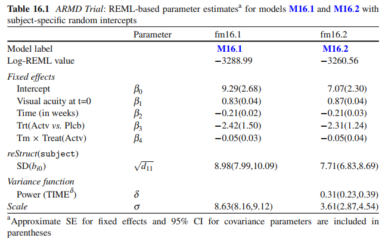

By default, `lme()` assumes independent residual errors with a constant variance, $\sigma^2$. Also, because there is no method argument in the `lme()` function call, the default **REML** estimation is used.

Note that, the p-values, corresponding to the t-test statistics for the fixed-effects coefficients, are for the marginal-approach tests.

```r
getGroupsFormula(fm16.1) # Grouping formula
```

```
## ~subject
## <environment: 0x0000000028f93b18>
```

```r
str(grpF <- getGroups(fm16.1)) # Grouping factor
```

```
##  Factor w/ 234 levels "1","2","3","4",..: 1 1 2 2 2 2 3 3 3 4 ...
##  - attr(*, "label")= chr "subject"
```

```r
# getGroups(fm16.1)
levels(grpF)
```

```
##   [1] "1"   "2"   "3"   "4"   "6"   "7"   "8"   "9"   "10"  "11"  "12"  "13"
##  [13] "14"  "15"  "16"  "17"  "18"  "19"  "20"  "22"  "23"  "24"  "25"  "26"
##  [25] "27"  "29"  "30"  "31"  "32"  "33"  "34"  "35"  "36"  "37"  "38"  "39"
##  [37] "40"  "41"  "42"  "43"  "44"  "45"  "46"  "47"  "49"  "50"  "51"  "52"
##  [49] "53"  "54"  "55"  "56"  "57"  "58"  "59"  "60"  "61"  "62"  "63"  "64"
##  [61] "65"  "66"  "67"  "68"  "69"  "70"  "71"  "72"  "73"  "74"  "75"  "76"
##  [73] "77"  "78"  "79"  "80"  "81"  "82"  "83"  "84"  "85"  "86"  "87"  "88"
##  [85] "89"  "90"  "91"  "92"  "93"  "94"  "95"  "96"  "97"  "98"  "99"  "100"
##  [97] "101" "102" "103" "104" "105" "106" "107" "108" "109" "110" "111" "112"
## [109] "113" "114" "115" "116" "117" "118" "119" "120" "121" "122" "123" "124"
## [121] "125" "126" "127" "128" "129" "130" "131" "132" "133" "134" "135" "136"
## [133] "137" "138" "139" "140" "141" "142" "143" "145" "146" "147" "148" "149"
## [145] "150" "151" "152" "153" "154" "155" "156" "157" "158" "159" "160" "161"
## [157] "162" "163" "164" "165" "166" "167" "168" "169" "170" "171" "172" "173"
## [169] "174" "175" "176" "177" "178" "179" "180" "181" "182" "183" "184" "185"
## [181] "186" "187" "188" "190" "191" "192" "193" "194" "195" "196" "197" "198"
## [193] "199" "200" "201" "202" "203" "204" "205" "206" "207" "208" "209" "210"
## [205] "211" "212" "213" "214" "215" "216" "217" "218" "219" "220" "221" "222"
## [217] "223" "224" "225" "226" "227" "228" "229" "230" "231" "232" "233" "234"
## [229] "235" "236" "237" "238" "239" "240"
```

```r
range(xtabs(~grpF))
```

```
## [1] 1 4
```

By using the function `getGroupsFormula()` (see Panel R14.5), we obtain the conditioning expression used in the specification of the random argument.

It indicates a single level of grouping, defined by the levels of the factor subject. By applying the function `getGroups()` to the model-fit object, we extract the grouping factor and store it in the object **grpF**.

```r
## (a) The D-matrix estimate
## d_11
getVarCov(fm16.1, individual = "2")
```

```
## Random effects variance covariance matrix
##             (Intercept)
## (Intercept)      80.608
##   Standard Deviations: 8.9782
```

```r
getVarCov(fm16.1, individual = "6")
```

```
## Random effects variance covariance matrix
##             (Intercept)
## (Intercept)      80.608
##   Standard Deviations: 8.9782
```

```r
## d_11 \sigma
VarCorr(fm16.1)
```

```
## subject = pdLogChol(1)
##             Variance StdDev
## (Intercept) 80.60829 8.978212
## Residual    74.43401 8.627514
```

```r
## (b) The Ri-matrix estimate
getVarCov(fm16.1,
          type = "conditional", # Ri:(16.6)
          individual = "6")
```

```
## subject 6
## Conditional variance covariance matrix
##        1      2      3      4
## 1 74.434  0.000  0.000  0.000
## 2  0.000 74.434  0.000  0.000
## 3  0.000  0.000 74.434  0.000
## 4  0.000  0.000  0.000 74.434
##   Standard Deviations: 8.6275 8.6275 8.6275 8.6275
```

```r
getVarCov(fm16.1,
          type = "conditional", # Ri:(16.6)
          individual = "2")
```

```
## subject 2
## Conditional variance covariance matrix
##        1      2      3      4
## 1 74.434  0.000  0.000  0.000
## 2  0.000 74.434  0.000  0.000
## 3  0.000  0.000 74.434  0.000
## 4  0.000  0.000  0.000 74.434
##   Standard Deviations: 8.6275 8.6275 8.6275 8.6275
```

```r
(fm16.1cov <- getVarCov(fm16.1,
                       type = "marginal", # Vi:(16.7)
                       individual = "2"))
```

```
## subject 2
## Marginal variance covariance matrix
##         1       2       3       4
## 1 155.040  80.608  80.608  80.608
## 2  80.608 155.040  80.608  80.608
## 3  80.608  80.608 155.040  80.608
## 4  80.608  80.608  80.608 155.040
##   Standard Deviations: 12.452 12.452 12.452 12.452
```

```r
(cov2cor(fm16.1cov[[1]])) # Corr(Vi)
```

```
##           1         2         3         4
## 1 1.0000000 0.5199116 0.5199116 0.5199116
## 2 0.5199116 1.0000000 0.5199116 0.5199116
## 3 0.5199116 0.5199116 1.0000000 0.5199116
## 4 0.5199116 0.5199116 0.5199116 1.0000000
```

The `getVarCov()`-function call, used in Panel R16.3a, does not include the type argument (see Sect. 14.6 and Table 14.5).

This means that the default value of the argument, i.e., `type="random.effect"`, is employed.

In the case of model M16.1, it gives the estimated variance and standard deviation of the subject-specific random intercepts. The argument `individual="2"`, used in the `getVarCov()`-function call, requests the random effects variance-covariance matrix for the second individual, i.e., `subject==2`, in the analyzed dataset.

In fact, in our case, the subject number is not of importance, as the variance-covariance structure of random effects is assumed to be the same for all individuals.

Finally, we obtain the estimated marginal variance-covariance matrix, defined in (16.7), by applying the function `getVarCov()` with the `type="marginal"` argument. The result, for `individual="2"`, is stored in the object **fm16.1cov** and displayed.

As noted earlier, the estimated marginal correlation matrix implies a constant, positive correlation coefficient equal to 0.52 for any two visual acuity measurements obtained for the same patient at different timepoints.

## 16.3 A Model with Random Intercepts and the `varPower(·)` Residual Variance-Function

### 16.3.1 Model Specification

To specify the new model, labeled M16.2, we use the same fixed-effects part as in model M16.1. However, we modify the variance-covariance structure of residual random errors, specified in (16.6).

$$\pmb {\mathcal R}_i = \sigma^2
\begin{pmatrix}
(TIME_{i1})^{2\delta} & 0 & 0 & 0 \\
0 & (TIME_{i2})^{2\delta} & 0 & 0 \\
0 & 0 & (TIME_{i3})^{2\delta} & 0 \\
0 & 0 & 0 & (TIME_{i4})^{2\delta}
\end{pmatrix}. (16.8)$$

Note that $\pmb {\mathcal R}_i = \sigma^2 \pmb \Lambda_i \pmb C_i \pmb \Lambda_i$ using $\pmb \Lambda_i$, given in (12.3), and by setting $\pmb C_i = \pmb I_4$.

It should be stressed here that the parameter $\sigma^2$, used in (16.8), can only be interpreted as a (unknown) scale parameter. This is in contrast to (16.6), where it could be interpreted as the variance of residual errors.

The matrix $\pmb {\mathcal R}_i$, given in (16.8), is diagonal with unequal elements defined by the `varPower(·)` function.

$$\pmb {\mathcal V}_i =
\begin{pmatrix}
\sigma^2_1 + d_{11} & d_{11} & d_{11} & d_{11} \\
d_{11} & \sigma^2_2 + d_{11} & d_{11} & d_{11}\\
d_{11} & d_{11} & \sigma^2_3 + d_{11} & d_{11}\\
d_{11} & d_{11} & d_{11} & \sigma^2_4 + d_{11}
\end{pmatrix}, (16.9) \ \ \ with\
\sigma^2_t = \sigma^2(TIME_{it})^{2\delta}$$

It is worth observing that, because the variance changes with time, the marginal correlation coefficients between observations made at different times are no longer equal.

```r
(fm16.2 <- # M16.2 from M16.1
   update(fm16.1,
          weights = varPower(form = ~ time), # (9.4)
          data = armd))
```

```
## Linear mixed-effects model fit by REML
##   Data: armd
##   Log-restricted-likelihood: -3260.563
##   Fixed: visual ~ visual0 + time + treat.f + treat.f:time
##        (Intercept)            visual0               time      treat.fActive
##         7.06688073         0.86654380        -0.21262732        -2.30503375
## time:treat.fActive
##        -0.05088779
##
## Random effects:
##  Formula: ~1 | subject
##         (Intercept) Residual
## StdDev:    7.705553 3.606684
##
## Variance function:
##  Structure: Power of variance covariate
##  Formula: ~time
##  Parameter estimates:
##     power
## 0.3144089
## Number of Observations: 867
## Number of Groups: 234
```

The results, indicate that the scale parameter $\sigma$ is estimated to be equal to 3.607.

The power coefficient $\delta$ of the `varPower()` variance function, as specified in (9.4), is estimated to be equal to 0.314.

The estimate of the standard deviation of the random intercepts $\sigma_b$ equals 7.706.

```r
# d_11: (16.6), \sigma^2
VarCorr(fm16.2)
```

```
## subject = pdLogChol(1)
##             Variance StdDev
## (Intercept) 59.37555 7.705553
## Residual    13.00817 3.606684
```

```r
# R_i: (16.8)
getVarCov(fm16.2,
          type = "conditional",
          individual = "6")
```

```
## subject 6
## Conditional variance covariance matrix
##        1      2      3      4
## 1 31.103  0.000  0.000   0.00
## 2  0.000 62.062  0.000   0.00
## 3  0.000  0.000 95.966   0.00
## 4  0.000  0.000  0.000 156.05
##   Standard Deviations: 5.577 7.8779 9.7962 12.492
```

```r
# Vi: (16.9)
(fm16.2cov <-
    getVarCov(fm16.2,
              type = "marginal",
              individual = "2"))
```

```
## subject 2
## Marginal variance covariance matrix
##        1       2       3       4
## 1 90.479  59.376  59.376  59.376
## 2 59.376 121.440  59.376  59.376
## 3 59.376  59.376 155.340  59.376
## 4 59.376  59.376  59.376 215.430
##   Standard Deviations: 9.512 11.02 12.464 14.677
```

```r
cov2cor(fm16.2cov[[1]])
```

```
##           1         2         3         4
## 1 1.0000000 0.5664462 0.5008307 0.4252890
## 2 0.5664462 1.0000000 0.4323024 0.3670969
## 3 0.5008307 0.4323024 1.0000000 0.3245735
## 4 0.4252890 0.3670969 0.3245735 1.0000000
```

Note that it is smaller than the value of 80.608, obtained for model M16.1 (see Panel R16.3).

This is expected, because, by allowing for heteroscedastic residual random errors, a larger part of the total variability is explained by the residual variances

[figure not shown]

It corresponds to the matrix specified in (16.8). Thus, for instance, the first diagonal element of the $\pmb {\mathcal R}_i$ matrix is equal to $\sigma^2 \times 4^{2 \hat \delta} = 3.6067^2 ·4^{2·0.3144} = 31.103$.

### 16.3.3 Diagnostic Plots

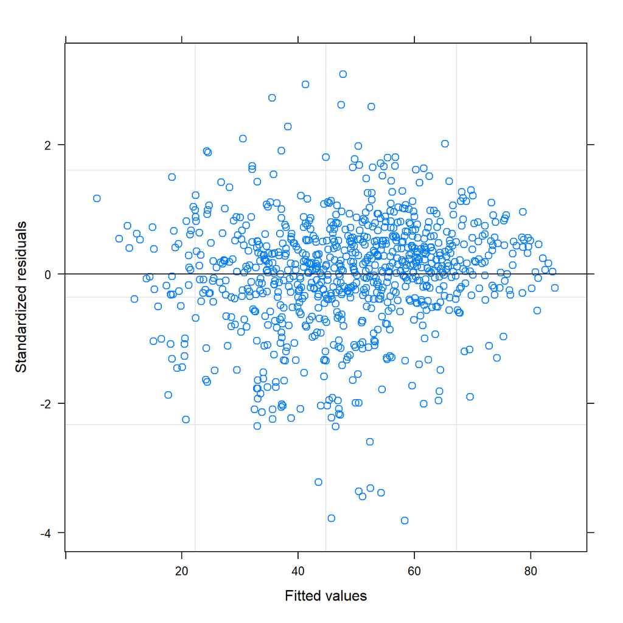

```r
## (a) Default residual plot of conditional Pearson residuals
plot(fm16.2)
```

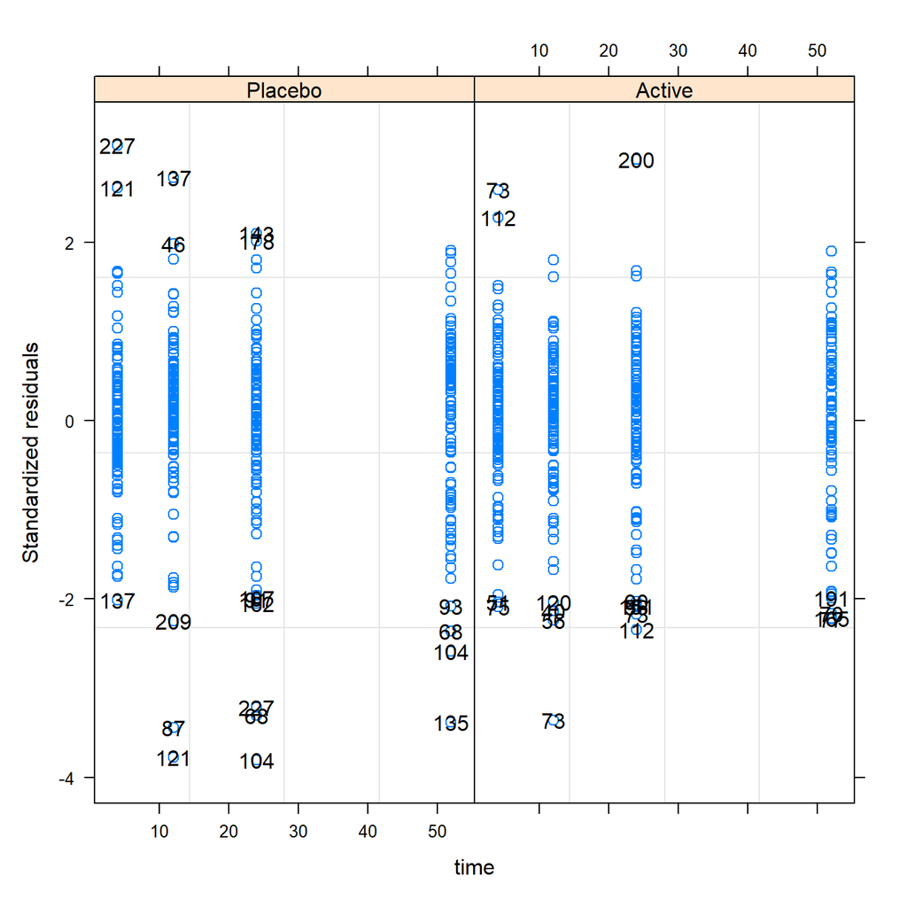

```r
## (b) Plots (and boxplots) of Pearson residuals per time and treatment
plot(fm16.2, # Figure not shown
     resid(., type = "pearson") ~ time | treat.f,
     id = 0.05)
```

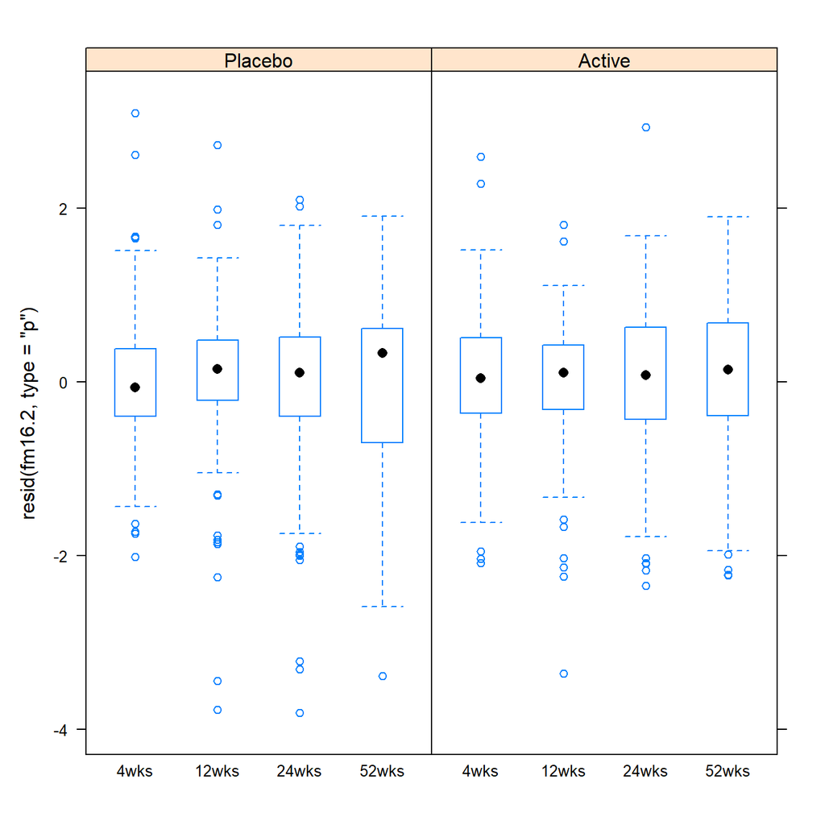

```r
lattice::bwplot(resid(fm16.2, type = "p") ~ time.f | treat.f, # Fig. 16.2
                data = armd)
```

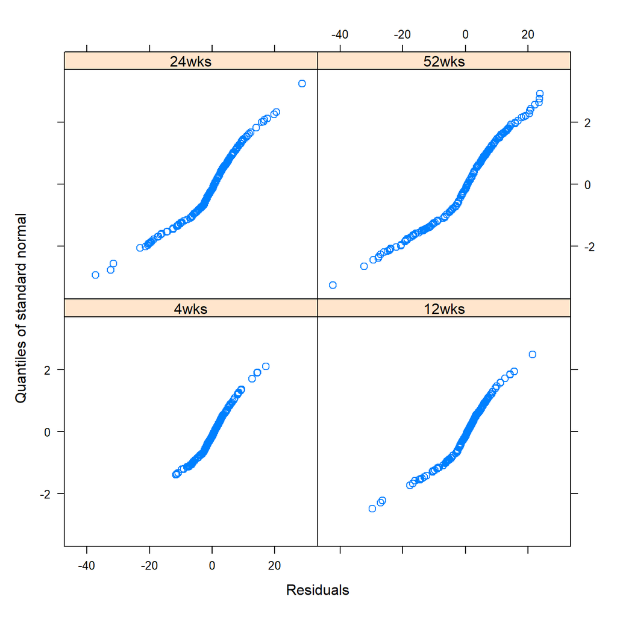

```r
## (c) Normal Q-Q plots of Pearson residuals and predicted random effects
## random error terms by timepoints
qqnorm(fm16.2, ~resid(.) | time.f)
```

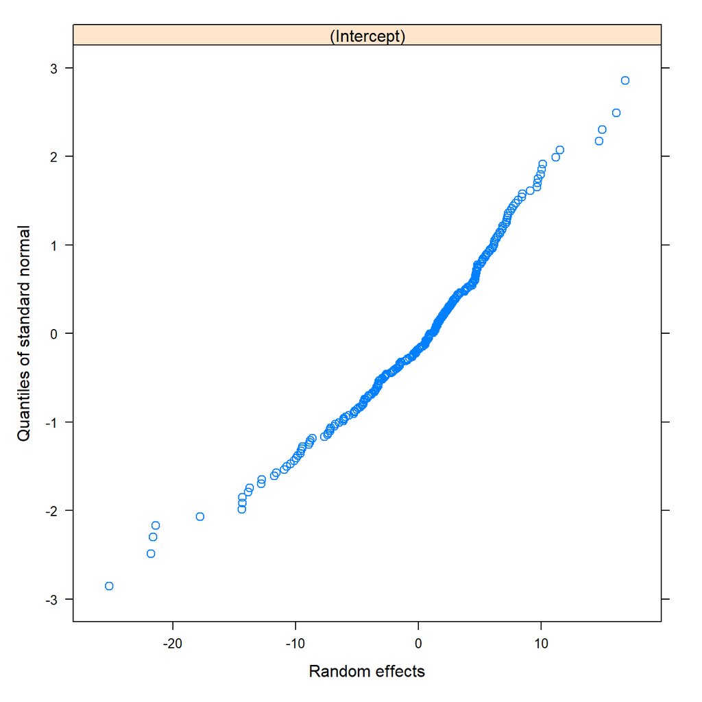

```r
## random effects
## The effects are estimated by EBLUPs (Sect. 13.6.1)
qqnorm(fm16.2, ~ranef(.))
```

```r
id <- 0.05
outliers.idx <-
  within(armd, {
    resid.p <- resid(fm16.2, type = "pearson") # Pearson resids.
    idx <- abs(resid.p) > -qnorm(id / 2) # Indicator vector
  })
outliers <- subset(outliers.idx, idx) # Data with outliers
nrow(outliers) # Number of outliers
```

```
## [1] 38
```

```r
outliers$subject
```

```
##  [1] 40  46  51  56  56  68  68  70  73  73  73  75  77  87  90  91  93  104 104
## [20] 107 112 112 120 121 121 135 137 137 143 151 162 165 178 191 200 209 227 227
## 234 Levels: 1 2 3 4 6 7 8 9 10 11 12 13 14 15 16 17 18 19 20 22 23 24 25 ... 240
```

The plot displays the conditional Pearson residuals (Sect. 13.6.2) versus fitted values. As such, the plot is not very informative, because it pools all the residuals together, despite the fact that residuals obtained from the same individual are potentially correlated. However, it can serve for detecting, e.g., outliers.

A modified plot of the residuals for each timepoint and treatment group might be more helpful.

Toward this end, we use the form of the plot()-function call shown in Panel R16.7b.

Note that, in the plot formula, we apply the `type="pearson"` argument in the `resid()` function, which indicates the use of the Pearson residuals.

Moreover, in the formula, we use the `term ~time|treat` to obtain plots per treatment group over time in separate panels.

Additionally, by applying the argument `id=0.05` to the `plot()` statement, we label the residuals larger, in absolute value, than the 97.5th percentile of the standard normal distribution by the number of the corresponding observation from the **armd** data frame.

**The resulting Q-Q plot is shown in Fig. 16.4 and is slightly curvilinear. This could be taken as an indication of non-normality of the random effects.** such a plot may not necessarily reflect the true distribution of the random effects. Hence, it should be interpreted with caution.

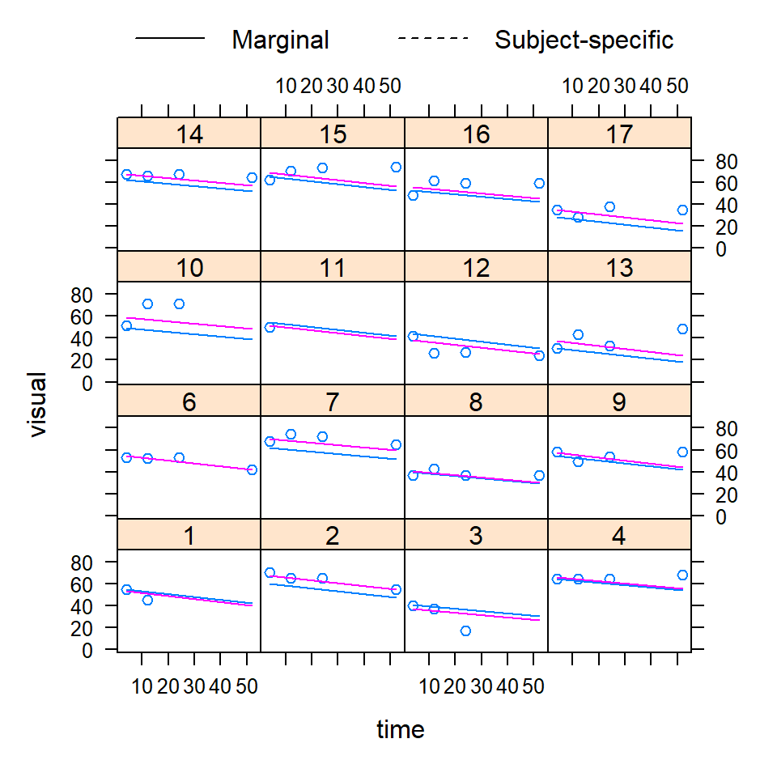

```r
aug.Pred <- # augPred for M16.2
augPred(fm16.2,
        primary = ~time, # Primary covariate
        level = 0:1, # Marginal(0) and subj.-spec.(1)
        length.out = 2)
plot(aug.Pred, layout = c(4, 4, 1), # Fig. 16.5
     key = list(lines = list(lty = c(1,2)),
                text = list(c("Marginal", "Subject-specific")),
                columns = 2))
```

```r
## augmented prediction
# ?augPred
# augPred(object,
#         primary = NULL,
#         minimum = min(primary),
#         maximum = max(primary),
#         length.out = 51,
#         level = Q,
#         ...)
```

The function `augPred()` allows obtaining predicted values for the object specified as the first argument. The object can be of class `lmList (14.5)`, `gls (11.6)`, and `lme (14.6)`.

The optional arguments of the function augPred() include: primary, level, length.out, minimum, and maximum. The argument primary is a one-sided formula indicating the covariate at which values the predicted values should be computed.

The argument level of the function `augPred()` is an integer vector specifying the grouping levels for which the predicted values are to be computed.

Its interpretation is the same as for the function `predict()` (Sect. 14.6). In the augPred-function call shown in Panel R16.9, we use level=0:1, which amounts to specifying that the predicted values should be computed at the level 0, i.e., the population level, and at the level 1, i.e., the subject level.

## 16.4 Models with Random Intercepts and Slopes and the `varPower(·)` Residual Variance-Function

### 16.4.1 Model with a General Matrix D

$$\begin{split}
VISUAL_{it} = & \beta_0 + \beta_1 \times VISUAL0_{i} + \beta_2 \times TIME_{it} + \beta_3 × TREAT_i \\
& + \beta_4 \times TREAT_i \times TIME_{it} \\
& + b_{0i} + b_{2i} × TIME_{it} + \epsilon_{it}. (16.10)\\
\end{split}$$

$$Zi = \begin{pmatrix}
1 & 4\\
1 & 12\\
1 & 24\\
1 & 52
\end{pmatrix}, \ \
bi = \begin{pmatrix}
b_{0i}\\
b_{2i}
\end{pmatrix}, (6.11)$$

$$\pmb b_i \sim (\pmb 0,\ \pmb {\mathcal D})\ and\ \pmb \epsilon_i \sim (\pmb 0,\ \pmb {\mathcal R}_i)\\
\pmb {\mathcal D} \equiv \begin{pmatrix}
d_{11} & d_{12}\\
d_{21} & d_{22}
\end{pmatrix}$$

Note that the assumed form of $\pmb {\mathcal D}$ implies that the random intercepts and slopes are correlated.

For instance, a positive correlation between $b_{0i}$ and $b_{2i}$ means that, for individuals with a higher initial value of visual acuity, the post-randomization measurements will increase more rapidly or decrease more slowly than for patients with a lower initial value.

$$\begin{split}
Cov(y_{it_1}, y_{it_2}) = &
\begin{pmatrix}
1 & TIME_{it_1}
\end{pmatrix} \pmb {\mathcal D}
\begin{pmatrix}
1 \\ TIME_{it_2}
\end{pmatrix} + \pmb I(t_1 = t_2)\sigma^2 (TIME_{it_1})^{2\delta} \\
= \ & d_{11} + d_{12}(TIME_{it_1} + TIME_{it_2}) + d_{22} TIME_{it_1} TIME_{it_2} \\
+ \ &\pmb I(t_1 = t_2 )\sigma^2 (TIME_{it})^{2\delta}, (16.14)\\
Var(y_{it}) = & d_{11} + 2d_{12} TIME_{it} + d_{22}TIME^2_{it} + \sigma^2(TIME_{it})^{2\delta}. (16.15)
\end{split}$$

By applying this particular formula in the random argument, we imply that, for each level of the subject grouping variable, a random intercept and a random slope for time are to be considered, with a (default) general variance-covariance matrix $\pmb {\mathcal D}$ represented by an object of class `pdLogChol`.

The results show a low estimated value of the correlation coefficient for the random effects $b_{0i}$ and $b_{2i}$, equal to 0.138. The confidence interval for the correlation coefficient suggests that, in fact, the two random effects can be uncorrelated.

```r
fm16.3 <- # M16.3 ← M16.2
 update(fm16.2,
        random = ~1 + time | subject,
        data = armd)
getVarCov(fm16.3, individual = "2") # D: (16.16)
```

```
## Random effects variance covariance matrix
##             (Intercept)    time
## (Intercept)    48.70500 0.26266
## time            0.26266 0.07412
##   Standard Deviations: 6.9789 0.27225
```

```r
intervals(fm16.3, which = "var-cov")
```

```
## Approximate 95% confidence intervals
##
##  Random Effects:
##   Level: subject
##                            lower      est.     upper
## sd((Intercept))        5.9931243 6.9789085 8.1268401
## sd(time)               0.2301543 0.2722504 0.3220461
## cor((Intercept),time) -0.1215431 0.1382424 0.3803029
##
##  Variance function:
##            lower      est.     upper
## power 0.01728109 0.1074438 0.1976066
## attr(,"label")
## [1] "Variance function:"
##
##  Within-group standard error:
##    lower     est.    upper
## 4.024129 5.122195 6.519892
```

### 16.4.2 Model with a Diagonal Matrix D

$$\pmb {\mathcal D} =
\begin{pmatrix}
d_{11} & 0 \\
0 & d_{22}
\end{pmatrix}, (16.16)$$

To fit model M16.4, we use the constructor-function `pdDiag()`. The function creates an object of class `pdDiag`, representing a diagonal positive-definite matrix

```r
(fm16.4 <- # M16.4 from M16.3
  update(fm16.3,
         random = list(subject = pdDiag(~1 + time)), # Diagonal D
         data = armd))
```

```
## Linear mixed-effects model fit by REML
##   Data: armd
##   Log-restricted-likelihood: -3215.896
##   Fixed: visual ~ visual0 + time + treat.f + treat.f:time
##        (Intercept)            visual0               time      treat.fActive
##          5.2622130          0.8999000         -0.2150309         -2.2787559
## time:treat.fActive
##         -0.0564510
##
## Random effects:
##  Formula: ~1 + time | subject
##  Structure: Diagonal
##         (Intercept)      time Residual
## StdDev:    7.231948 0.2809649 5.031159
##
## Variance function:
##  Structure: Power of variance covariate
##  Formula: ~time
##  Parameter estimates:
##     power
## 0.1110751
## Number of Observations: 867
## Number of Groups: 234
```

```r
intervals(fm16.4)
```

```
## Approximate 95% confidence intervals
##
##  Fixed effects:
##                         lower       est.       upper
## (Intercept)         0.8127705  5.2622130  9.71165548
## visual0             0.8246435  0.8999000  0.97515652
## time               -0.2795380 -0.2150309 -0.15052381
## treat.fActive      -4.5888197 -2.2787559  0.03130786
## time:treat.fActive -0.1505476 -0.0564510  0.03764565
## attr(,"label")
## [1] "Fixed effects:"
##
##  Random Effects:
##   Level: subject
##                     lower      est.     upper
## sd((Intercept)) 6.3306729 7.2319476 8.2615334
## sd(time)        0.2410843 0.2809649 0.3274426
##
##  Variance function:
##            lower      est.     upper
## power 0.01482336 0.1110751 0.2073269
## attr(,"label")
## [1] "Variance function:"
##
##  Within-group standard error:
##    lower     est.    upper
## 3.897875 5.031159 6.493939
```

```r
intervals(fm16.3, which = "var-cov")
```

```
## Approximate 95% confidence intervals
##
##  Random Effects:
##   Level: subject
##                            lower      est.     upper
## sd((Intercept))        5.9931243 6.9789085 8.1268401
## sd(time)               0.2301543 0.2722504 0.3220461
## cor((Intercept),time) -0.1215431 0.1382424 0.3803029
##
##  Variance function:
##            lower      est.     upper
## power 0.01728109 0.1074438 0.1976066
## attr(,"label")
## [1] "Variance function:"
##
##  Within-group standard error:
##    lower     est.    upper
## 4.024129 5.122195 6.519892
```

```r
intervals(fm16.4, which = "var-cov")
```

```
## Approximate 95% confidence intervals
##
##  Random Effects:
##   Level: subject
##                     lower      est.     upper
## sd((Intercept)) 6.3306729 7.2319476 8.2615334
## sd(time)        0.2410843 0.2809649 0.3274426
##
##  Variance function:
##            lower      est.     upper
## power 0.01482336 0.1110751 0.2073269
## attr(,"label")
## [1] "Variance function:"
##
##  Within-group standard error:
##    lower     est.    upper
## 3.897875 5.031159 6.493939
```

```r
## LRT for nested models
anova(fm16.4, fm16.3)
```

```
##        Model df      AIC      BIC    logLik   Test  L.Ratio p-value
## fm16.4     1  9 6449.792 6492.625 -3215.896
## fm16.3     2 10 6450.598 6498.190 -3215.299 1 vs 2 1.194014  0.2745
```

Panel R16.11 presents the 95% CIs for all the parameters of model M16.4. They suggest that the mean structure could be simplified by removing the **time:treat.f** interaction.

In Panel R16.12, we use the REML-based LR test (Sect. 13.7.2) to verify the null hypothesis that in the matrix D, defined in (16.13), the element $d_{12} = 0$.

$$Var(y_{it}) = d_{11} + d_{22} TIME^2_{it} + \sigma^2(TIME_{it})^{2\delta}.$$

Consequently, given that $\hat \delta = 0.11$, the implied marginal variance function is predominantly a quadratic function over time. As $d_{11}$, $d_{22}$, and $\sigma^2$ are necessarily positive, the function increases with time, which is in agreement with the observation made in the exploratory analysis.

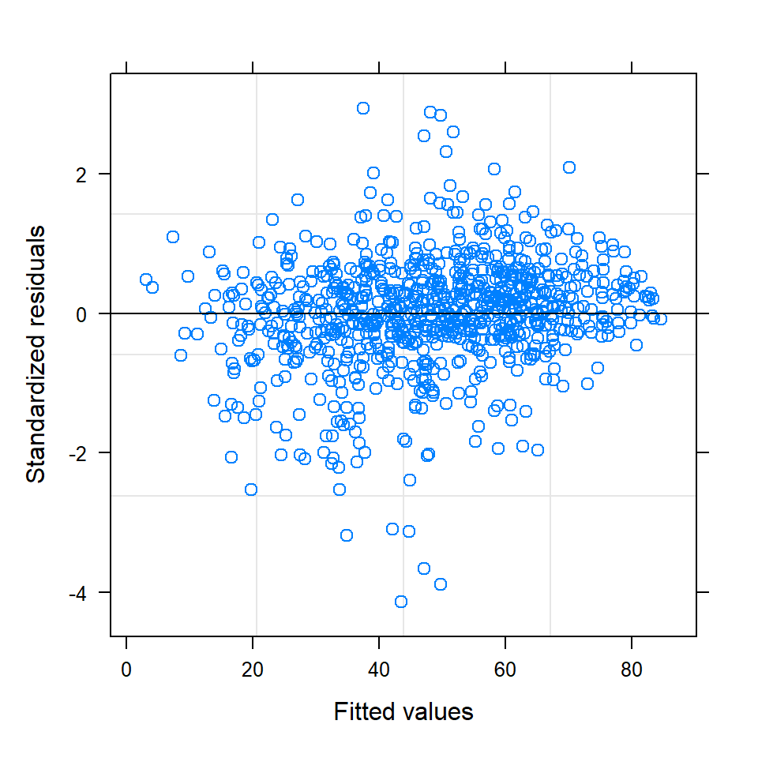

```r
plot(fm16.4)
```

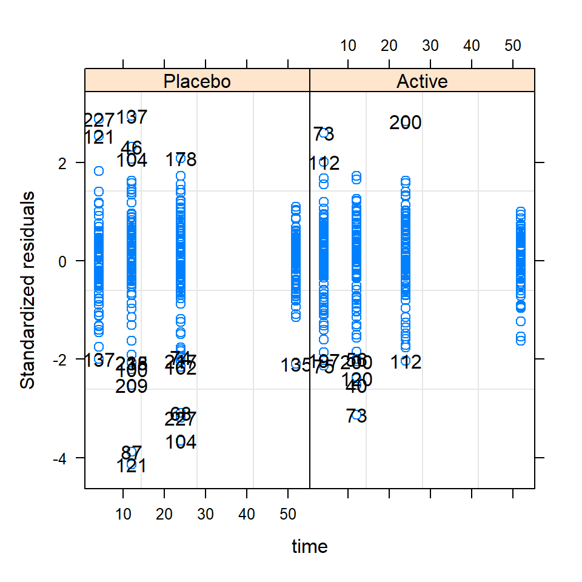

```r
## (b) Plots (and boxplots) of Pearson residuals per time and treatment
plot(fm16.4, # Figure not shown
     resid(., type = "pearson") ~ time | treat.f,
     id = 0.05)
```

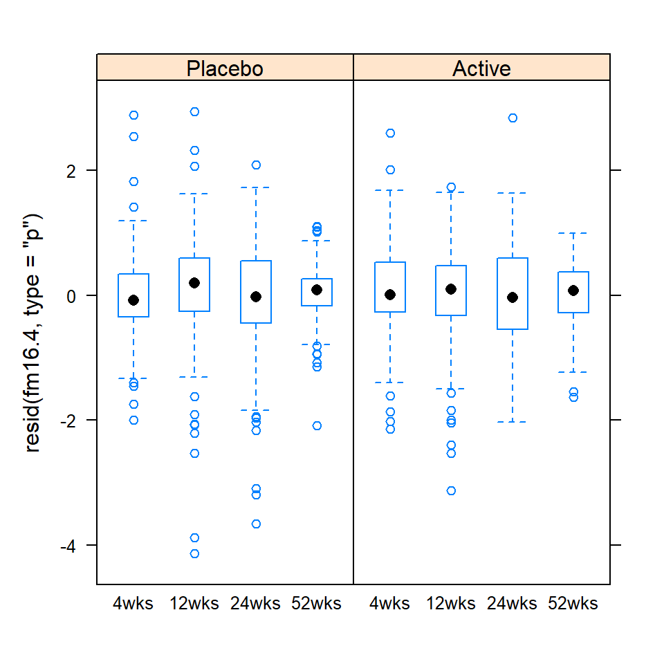

```r
lattice::bwplot(resid(fm16.4, type = "p") ~ time.f | treat.f,
                data = armd)
```

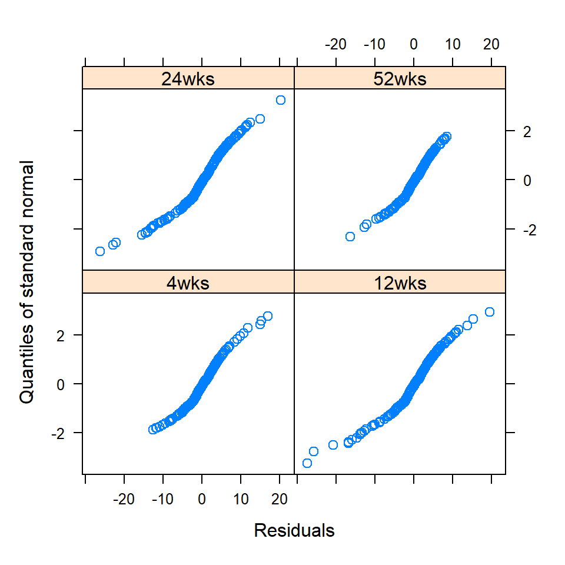

```r
## (c) Normal Q-Q plots of Pearson residuals and predicted random effects
## random error terms by timepoints
qqnorm(fm16.4, ~resid(.) | time.f)
```

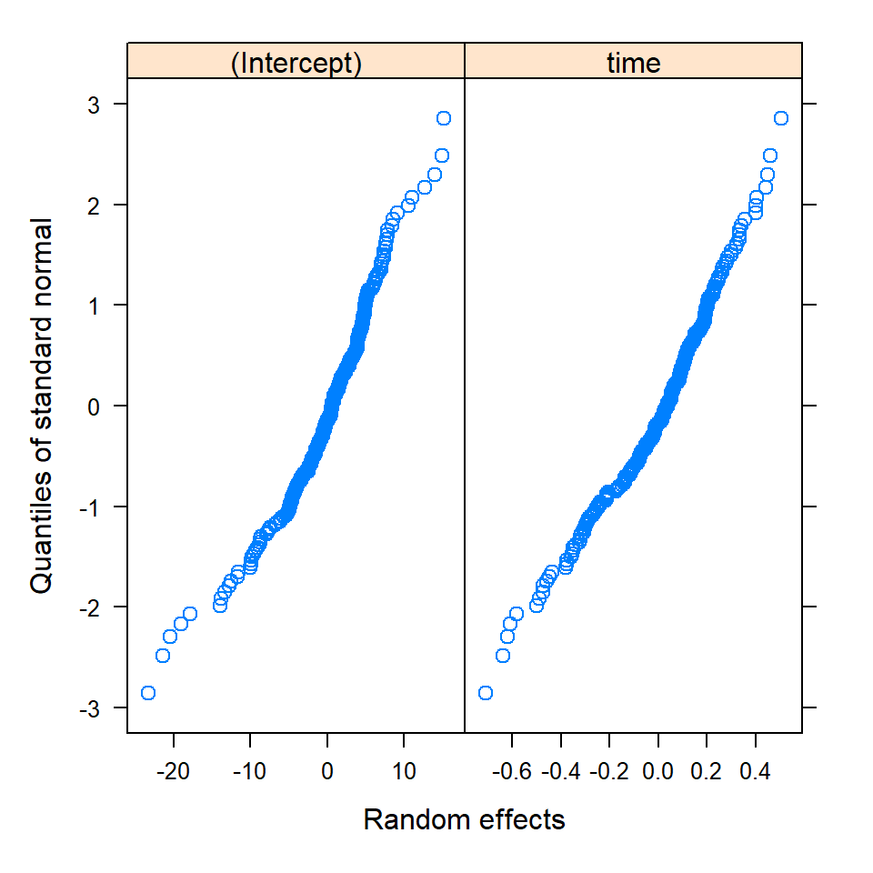

```r
## random effects
## The effects are estimated by EBLUPs (Sect. 13.6.1)
qqnorm(fm16.4, ~ranef(.))
```

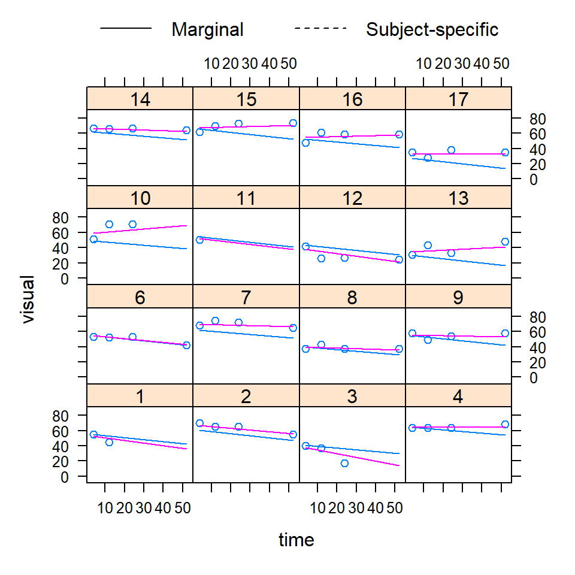

```r
aug.Pred <- # augPred for M16.2
  augPred(fm16.4,
    primary = ~time, # Primary covariate
    level = 0:1, # Marginal(0) and subj.-spec.(1)
    length.out = 2)
plot(aug.Pred,
  layout = c(4, 4, 1), # Fig. 16.5
  key = list(
    lines = list(lty = c(1, 2)),
    text = list(c("Marginal", "Subject-specific")),
    columns = 2))
```

## 16.4.3 Model with a Diagonal Matrix D and a Constant Treatment Effect

$$VISUAL_{it} = \beta_0 + \beta_1 \times VISUAL0_i + \beta_2 \times TIME_{it} + \beta_3 \times TREAT_i \\
+ b_{0i} + b_{2i} \times TIME_{it} + \epsilon_{it}. (16.17)$$

```r
lm3.form <- formula(visual ~ visual0 + time + treat.f) # (12.9)
fm16.5 <- # M16.5 ← M16.4
  update(fm16.4,
         lm3.form,
         data = armd)
summary(fm16.5)$tTable
```

```
##                    Value  Std.Error  DF    t-value      p-value
## (Intercept)    5.4415585 2.26186628 632   2.405783 1.642406e-02
## visual0        0.8998272 0.03821506 231  23.546405 2.550274e-63
## time          -0.2415596 0.02391747 632 -10.099712 2.464124e-22
## treat.fActive -2.6552826 1.12868317 231  -2.352549 1.948533e-02
```

```r
intervals(fm16.5, which = "var-cov")
```

```
## Approximate 95% confidence intervals
##
##  Random Effects:
##   Level: subject
##                     lower      est.     upper
## sd((Intercept)) 6.3344763 7.2356957 8.2651335
## sd(time)        0.2412146 0.2810238 0.3274029
##
##  Variance function:
##            lower      est.     upper
## power 0.01568704 0.1105193 0.2053517
## attr(,"label")
## [1] "Variance function:"
##
##  Within-group standard error:
##    lower     est.    upper
## 3.917726 5.039134 6.481533
```

```r
VarCorr(fm16.5) # D (16.16)
```

```
## subject = pdDiag(1 + time)
##             Variance    StdDev
## (Intercept) 52.35529259 7.2356957
## time         0.07897435 0.2810238
## Residual    25.39286774 5.0391336
```

```r
getVarCov(fm16.5, # Ri: (16.8)
          type = "conditional",
          individual = "2")
```

```
## subject 2
## Conditional variance covariance matrix
##        1     2      3      4
## 1 34.498  0.00  0.000  0.000
## 2  0.000 43.98  0.000  0.000
## 3  0.000  0.00 51.262  0.000
## 4  0.000  0.00  0.000 60.816
##   Standard Deviations: 5.8735 6.6317 7.1597 7.7984
```

```r
(fm16.5cov <- # Vi: (16.9)
  getVarCov(fm16.5,
    type = "marginal",
    individual = "2"))
```

```
## subject 2
## Marginal variance covariance matrix
##        1       2       3       4
## 1 88.117  56.146  59.937  68.782
## 2 56.146 107.710  75.100 101.640
## 3 59.937  75.100 149.110 150.920
## 4 68.782 101.640 150.920 326.720
##   Standard Deviations: 9.387 10.378 12.211 18.075
```

```r
cov2cor(fm16.5cov[[1]])
```

```
##           1         2         3         4
## 1 1.0000000 0.5763255 0.5228983 0.4053773
## 2 0.5763255 1.0000000 0.5926101 0.5417959
## 3 0.5228983 0.5926101 1.0000000 0.6837531
## 4 0.4053773 0.5417959 0.6837531 1.0000000
```

Note that these are the marginal-approach tests (Sect. 5.6). Thus, the effect of each covariate is tested under the assumption that all other covariates are included in the model as well.

It suggests a time-independent, negative average effect of the active treatment. This finding is in agreement with the results of the exploratory analysis (Sect. 3.2) and of the previous analysis using an LM with fixed effects for correlated data .

The estimated marginal variance-covariance matrix indicates an increasing trend of variances of visual acuity measurements over time, while the corresponding correlation matrix suggests a decreasing correlation between the measurements obtained at more distant timepoints.

These findings are in agreement with the results of the exploratory analysis (Sect. 3.2) and with the results obtained for model M12.3 for correlated data (Table 12.2).

Note, however, that a direct comparison of the estimated marginal matrices to their counterparts obtained for model M12.3 is not appropriate, because the matrices for model M16.5 are much more structured than those of model M12.3

## 16.5 An Alternative Residual Variance Function: varIdent(·)

$$\pmb {\mathcal R}_i =
\sigma^2_1
\begin{pmatrix}
1 & 0 & 0 & 0 \\
0 & \sigma^2_2 / \sigma_1^2 & 0 & 0 \\
0 & 0 & \sigma^2_3 / \sigma_1^2 & 0 \\
0 & 0 & 0 & \sigma^2_4 / \sigma_1^2
\end{pmatrix}
=
\sigma^2
\begin{pmatrix}
\delta_1^2 & 0 & 0 & 0 \\
0 & \delta_2^2 & 0 & 0 \\
0 & 0 & \delta_3^2 & 0 \\
0 & 0 & 0 & \delta_1^2
\end{pmatrix}$$

where $\delta_t \equiv \sigma_t/\sigma_1 (t = 1,...,4)$ is the ratio of SD of the visual acuity measurements at occasion $t$ relative to SD of the measurements at the first occasion, and where $\sigma^2 \equiv \sigma^2_1$.

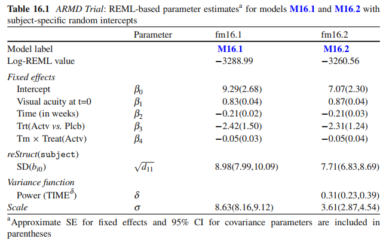

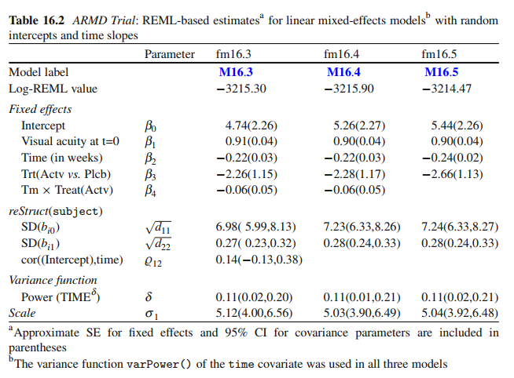

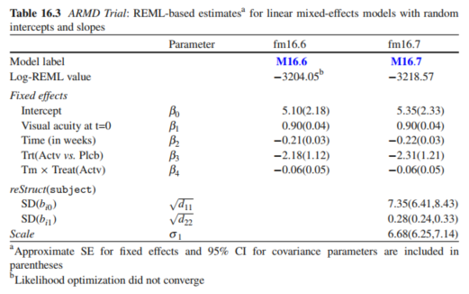